[**Imtiaj.**](https://imtiajiqbalmahfuj.github.io/index.html#top)

# El Niño-Driven Agrarian Moisture Stress Analysis

### Spatio-temporal evaluation and machine learning prediction of agricultural vulnerability in the Barind Tract, Bangladesh.

> *Mapping the creeping threat of climate-induced moisture stress and agricultural vulnerability using Google Earth Engine and Machine Learning.* 🌍🌾

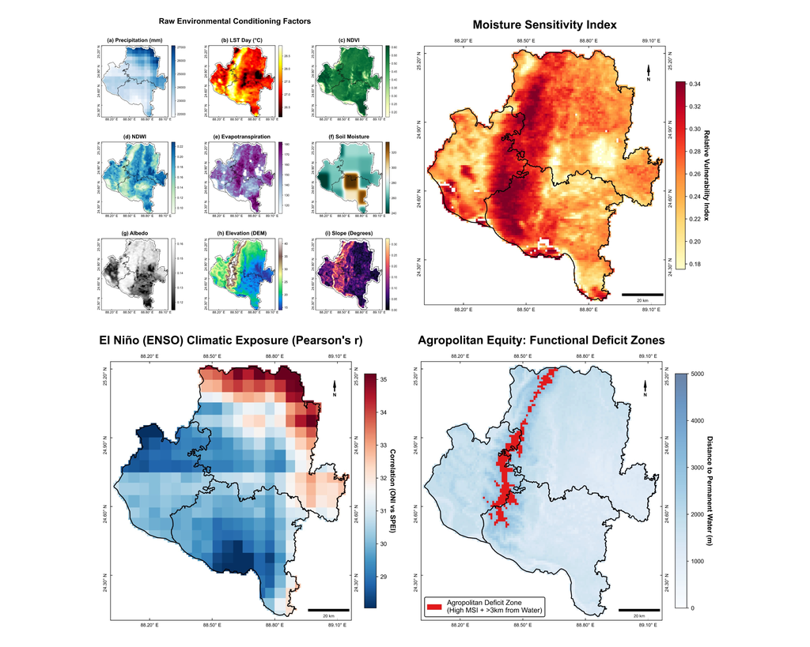

> **Author:** Imtiaj Iqbal Mahfuj

## 📝 Overview

This project explores **spatial patterns**, integrates **remote sensing datasets**, and applies **geospatial Python tools** to visualize and analyze El Niño-driven moisture stress in the Barind Tract of Bangladesh. Comprising the Rajshahi, Naogaon, and Nawabganj districts, this region is highly susceptible to climatic extremes. The project aims to uncover key insights that support data-driven decision-making for sustainable agriculture and equitable water resource planning.

The primary objective is to develop a comprehensive framework that evaluates agrarian vulnerability by synthesizing multiple environmental factors. Using a 15-year monitoring window (2010–2025), the study models the spatial footprint of moisture deficits, evaluates long-term regional convergence of vulnerability, and identifies critical infrastructural gaps (Agropolitan Equity).

This robust methodology directly benefits urban and regional planners, agronomists, climate researchers, and policy-makers. By pinpointing highly vulnerable spatial clusters and functional deficit regions (areas distant from permanent surface water), it empowers stakeholders to prioritize interventions such as irrigation expansion and drought-resilient crop planning.

In summary, the project harnesses Google Earth Engine (GEE) to extract nine distinct environmental parameters, applying Principal Component Analysis (PCA) to derive a normalized Moisture Sensitivity Index (MSI). Furthermore, it leverages Scikit-Learn to train a Random Forest classifier (achieving an AUC of 0.980) to predict drought-prone areas, revealing that precipitation, albedo, and NDVI are the most critical predictors of moisture stress.

## 🛠️ Tools & Technologies

## ⚙️ Methodology

| Step | Description |
| --- | --- |
| 1. Data Collection | Fetching CHIRPS (Precipitation), MODIS (LST, NDVI, NDWI, ET, Albedo), GLDAS (Soil Moisture), and SRTM (Elevation, Slope) via GEE. |
| 2. Preprocessing | Applying strict binary masks, Gaussian smoothing, physical scaling, and automated conversion to NumPy/Pandas dataframes. |
| 3. Analysis | Supervised ML (Random Forest, Gradient Boosting) for feature importance; PCA for MSI weighting; Spatio-temporal $\sigma$-convergence. |
| 4. Visualization | Generating high-DPI (500), IEEE publication-ready grids and multi-panel maps with customized scales, north arrows, and dynamic colorbars. |

## Environment Setup

```python
import os
import matplotlib.pyplot as plt
import numpy as np
import pandas as pd
import ee
import geemap
import geopandas as gpd
from shapely.geometry import Point
from matplotlib_scalebar.scalebar import ScaleBar
from matplotlib.ticker import MaxNLocator, FuncFormatter
import warnings
warnings.filterwarnings('ignore')

# Initialize Earth Engine
try:
    ee.Initialize()
except Exception as e:
    ee.Authenticate()
    ee.Initialize()

# Create directory for high-DPI IEEE exports
os.makedirs('Exports', exist_ok=True)

# IEEE Journal Publication Styling (Strict Serif, High DPI)
# Reference: IEEE Author Center Graphics Guidelines
plt.rcParams.update({
    'font.family': 'sans-serif',
    'font.sans-serif': ['Arial', 'Helvetica', 'DejaVu Sans'],
    'text.usetex': False,            # Prevents LaTeX rendering engines from introducing blurry halos
    'mathtext.fontset': 'cm',        # Standard clean math typography block
    'font.size': 13,
    'axes.titlesize': 14,
    'axes.labelsize': 14,
    'xtick.labelsize': 14,
    'ytick.labelsize': 14,
    'legend.fontsize': 12,
    'figure.dpi': 500,               # Maintained high resolution for exports
    'savefig.dpi': 500,
    'savefig.bbox': 'tight'
})

def apply_custom_map_style(ax, reference_gdf, title="", tight=False, is_factor_grid=False):
    """Applies IEEE standard mapping styles, scalebars, and North arrows."""
    if is_factor_grid:
        ax.tick_params(top=True, bottom=True, left=True, right=True,
                       direction='in', labeltop=False, labelbottom=True,
                       labelleft=True, labelright=False, pad=4, labelsize=7)
        ax.xaxis.set_major_locator(MaxNLocator(nbins=3, prune='both'))
        ax.yaxis.set_major_locator(MaxNLocator(nbins=3, prune='both'))
        ax.set_title(title, pad=12, fontweight='bold', fontsize=14)
    else:
        ax.tick_params(top=True, bottom=True, left=True, right=True,
                       direction='in', labeltop=True, labelbottom=True,
                       labelleft=True, labelright=True, pad=5, labelsize=8)
        ax.xaxis.set_major_locator(MaxNLocator(nbins=4, prune='both'))
        ax.yaxis.set_major_locator(MaxNLocator(nbins=4, prune='both'))
        ax.set_title(title, pad=30, fontweight='bold', fontsize=20)

    ax.tick_params(axis='y', labelrotation=90)
    ax.xaxis.set_major_formatter(FuncFormatter(lambda x, _: f"{x:.2f}° E"))
    ax.yaxis.set_major_formatter(FuncFormatter(lambda y, _: f"{y:.2f}° N"))

    # Add Scale Bar and North Arrow Elements
    projected_centroid = reference_gdf.to_crs(epsg=32646).geometry.centroid.to_crs(epsg=4326)
    center_lat = projected_centroid.y.iloc[0]
    deg_points = gpd.GeoSeries([Point(91.0, center_lat), Point(92.0, center_lat)], crs="EPSG:4326").to_crs(epsg=32646)
    meters_per_degree = deg_points.iloc[0].distance(deg_points.iloc[1])

    scalebar = ScaleBar(dx=meters_per_degree, units="m", location="lower right",
                        box_alpha=0.7, color='black', font_properties={'size': 7})
    ax.add_artist(scalebar)

    ax.annotate('N', xy=(0.93, 0.93), xytext=(0.93, 0.87),
                arrowprops=dict(facecolor='black', width=1.0, headwidth=4, shrink=0.05),
                ha='center', va='center', fontweight='bold', fontsize=8, xycoords='axes fraction')

    # Handle Frame Boundaries
    bounds = reference_gdf.total_bounds
    padding = 0.006 if tight else 0.016
    ax.set_xlim(bounds[0] - padding, bounds[2] + padding)
    ax.set_ylim(bounds[1] - padding, bounds[3] + padding)
```

## Study Area

```python
# Study Area Map: Perfect Masking, Centered Title, & Matched Legend

import os
import ee
import geemap
import copy
import numpy as np
import geopandas as gpd
import matplotlib.pyplot as plt
import matplotlib.lines as mlines
from matplotlib.ticker import MaxNLocator, FuncFormatter
from matplotlib.gridspec import GridSpec
from matplotlib_scalebar.scalebar import ScaleBar
from mpl_toolkits.axes_grid1.inset_locator import inset_axes
from mpl_toolkits.axes_grid1 import make_axes_locatable # Added for perfect legend sizing
import matplotlib.patches as mpatches
import contextily as cx

# 1. Initialize Earth Engine
try:
    ee.Initialize()
except Exception as e:
    ee.Authenticate()
    ee.Initialize()

# 2. Configuration & IEEE Styling
OUTPUT_DIR = "Exports"
os.makedirs(OUTPUT_DIR, exist_ok=True)

plt.rcParams.update({
    'font.family': 'sans-serif',
    'font.sans-serif': ['Arial', 'Helvetica', 'DejaVu Sans'],
    'font.size': 12,
    'axes.labelsize': 12,
    'xtick.labelsize': 10,
    'ytick.labelsize': 10,
    'figure.dpi': 500,
    'savefig.dpi': 500,
    'savefig.bbox': 'tight'
})

# 3. Define the Study Area
COUNTRY = 'Bangladesh'
DISTRICTS = ['Rajshahi', 'Naogaon', 'Nawabganj']

print(f"Fetching boundaries for {COUNTRY} and {', '.join(DISTRICTS)}...")

country_ee = ee.FeatureCollection("FAO/GAUL/2015/level0").filter(ee.Filter.eq('ADM0_NAME', COUNTRY))

districts_ee = ee.FeatureCollection("FAO/GAUL/2015/level2") \
    .filter(ee.Filter.eq('ADM0_NAME', COUNTRY)) \
    .filter(ee.Filter.inList('ADM2_NAME', DISTRICTS))

aoi_ee = districts_ee.geometry()

# Convert to GeoDataFrames
country_gdf = geemap.ee_to_gdf(country_ee)
districts_gdf = geemap.ee_to_gdf(districts_ee)
aoi_gdf = gpd.GeoDataFrame(geometry=[districts_gdf.unary_union], crs="EPSG:4326")

bounds = aoi_gdf.buffer(0.12).total_bounds
lon_min, lat_min, lon_max, lat_max = bounds

# 4. Fetch DEM specifically for the AOI
print("Fetching DEM Array with strict binary masking...")
dem = ee.Image("USGS/SRTMGL1_003").rename('elevation')

# CRITICAL FIX: Create a perfect 1/0 mask in Earth Engine to eliminate the blue box
mask_band = ee.Image(1).clip(aoi_ee).unmask(0).rename('ROI_MASK')
combined_dem = dem.addBands(mask_band).unmask(-9999)

dem_arr_raw = geemap.ee_to_numpy(combined_dem, region=aoi_ee, scale=90)
dem_arr = dem_arr_raw.astype(float)

dem_slice = dem_arr[:, :, 0]
mask_slice = dem_arr[:, :, 1]

# Enforce strict NaN transparency on anything outside the exact district lines
dem_slice = np.where(mask_slice == 1, dem_slice, np.nan)
dem_slice[dem_slice < -9000] = np.nan

dem_bounds = aoi_gdf.total_bounds
d_lon_min, d_lat_min, d_lon_max, d_lat_max = dem_bounds

# ==============================================================================
# 5. BUILD THE FIGURE AND TIGHT GRIDSPEC LAYOUT
# ==============================================================================
fig = plt.figure(figsize=(12, 9))

# CRITICAL FIX 2: Exactly center the title on the canvas
fig.suptitle("Study Area Map", fontsize=24, fontweight='bold', x=0.5, y=0.97, ha='center')

# Tighten the left edge to remove massive white space
fig.subplots_adjust(left=0.06, right=0.96, top=0.90, bottom=0.05)

# height_ratios=[2, 1] enforces the 2/3 and 1/3 split. wspace=0.02 pulls the center gap tighter.
gs = GridSpec(2, 2, width_ratios=[2.5, 1.1], height_ratios=[2, 1], wspace=0.02, hspace=0.08)

ax_main = fig.add_subplot(gs[:, 0])
ax_dem = fig.add_subplot(gs[0, 1])
ax_legend = fig.add_subplot(gs[1, 1])

# ---------------------------------------------------------
# PANEL A: MAIN MAP
# ---------------------------------------------------------
ax_main.set_xlim(lon_min, lon_max)
ax_main.set_ylim(lat_min, lat_max)

# Define dynamic variables so the map and legend auto-sync
poly_facecolor = '#FF4444'
poly_edgecolor = '#CC0000'

districts_gdf.plot(ax=ax_main, facecolor=poly_facecolor, alpha=0.35, zorder=2)
districts_gdf.boundary.plot(ax=ax_main, edgecolor=poly_edgecolor, linewidth=1.5, zorder=3)


print("Downloading high-res Esri basemap...")
cx.add_basemap(ax_main, crs="EPSG:4326", source=cx.providers.Esri.WorldTopoMap, alpha=0.85, zorder=1)

for idx, row in districts_gdf.iterrows():
    centroid = row.geometry.centroid
    # Removed the bbox parameter entirely and set color to black
    ax_main.text(centroid.x, centroid.y, row['ADM2_NAME'],
                 fontsize=15, fontweight='bold', color='black', ha='center', va='center', zorder=4)

ax_main.grid(True, linestyle='--', color='black', alpha=0.5, zorder=5)
ax_main.tick_params(top=True, bottom=True, left=True, right=True,
                    labeltop=True, labelbottom=True, labelleft=True, labelright=True,
                    direction='in', length=8, width=1.2, pad=6)
ax_main.tick_params(axis='y', labelrotation=90)
ax_main.xaxis.set_major_formatter(FuncFormatter(lambda x, _: f"{x:.2f}° E"))
ax_main.yaxis.set_major_formatter(FuncFormatter(lambda y, _: f"{y:.2f}° N"))
# Prunes the very first and last tick marks so they stop overhanging the borders
ax_main.xaxis.set_major_locator(MaxNLocator(nbins=5, prune='both'))
ax_main.yaxis.set_major_locator(MaxNLocator(nbins=5, prune='both'))

for spine in ax_main.spines.values():
    spine.set_linewidth(1.5)
    spine.set_zorder(6)

ax_main.annotate('N', xy=(0.95, 0.95), xytext=(0.95, 0.86),
                 arrowprops=dict(facecolor='black', width=3.0, headwidth=12, shrink=0.05),
                 ha='center', va='center', fontweight='bold', fontsize=18,
                 xycoords='axes fraction', textcoords='axes fraction', zorder=6)

center_lat = (lat_min + lat_max) / 2
meters_per_degree = 111320 * np.cos(np.radians(center_lat))
scalebar = ScaleBar(dx=meters_per_degree, units="m", location="lower left",
                    box_alpha=0.85, color='black', font_properties={'size': 12, 'weight': 'bold'})
scalebar.set_zorder(6)
ax_main.add_artist(scalebar)

# ---------------------------------------------------------
# PANEL B: DEM MAP (Top Right)
# ---------------------------------------------------------
ax_dem.set_facecolor('white')

cmap_dem = copy.copy(plt.get_cmap('terrain'))
cmap_dem.set_bad(color='white', alpha=0)

im_dem = ax_dem.imshow(dem_slice, cmap=cmap_dem, extent=[d_lon_min, d_lon_max, d_lat_min, d_lat_max])
districts_gdf.boundary.plot(ax=ax_dem, color='black', linewidth=1.2)
ax_dem.set_title("Elevation Profile", fontweight='bold', fontsize=14, pad=10)

# CRITICAL FIX: Forces the box to grow taller without stretching the map.
y_pad = (d_lat_max - d_lat_min) * 0.15
ax_dem.set_ylim(d_lat_min - (y_pad * 0.2), d_lat_max + y_pad) # Extra padding at the top for the Inset Map!

# CRITICAL FIX: Sub-divide ax_dem to attach the colorbar inside the same GridSpec cell
# This guarantees ax_legend perfectly matches their combined width below.
divider = make_axes_locatable(ax_dem)
cax = divider.append_axes("right", size="5%", pad=0.15)
cbar = plt.colorbar(im_dem, cax=cax)
cbar.set_label('Elevation (m)', weight='bold', fontsize=11)
cbar.ax.tick_params(labelsize=9)

ax_dem.tick_params(direction='in', labelsize=9)
ax_dem.tick_params(axis='y', labelrotation=90)
ax_dem.xaxis.set_major_formatter(FuncFormatter(lambda x, _: f"{x:.1f}°"))
ax_dem.yaxis.set_major_formatter(FuncFormatter(lambda y, _: f"{y:.1f}°"))
ax_dem.xaxis.set_major_locator(MaxNLocator(nbins=3, prune='both'))
ax_dem.yaxis.set_major_locator(MaxNLocator(nbins=3, prune='both'))

for spine in ax_dem.spines.values():
    spine.set_linewidth(1.2)

# Float the inset map in the empty white space at the top-left of the DEM panel
inset_ax = inset_axes(ax_dem, width="20%", height="20%", loc='upper left', borderpad=0.5)
country_gdf.plot(ax=inset_ax, color='lightgray', edgecolor='black', linewidth=0.5)
aoi_gdf.plot(ax=inset_ax, color='red', edgecolor='darkred', linewidth=1)

inset_ax.set_xticks([])
inset_ax.set_yticks([])
for spine in inset_ax.spines.values():
    spine.set_linewidth(1)
# inset_ax.set_title("Location", fontsize=9, weight='bold', pad=4)

# PANEL C: PERFECTLY MATCHED LEGEND (Bottom Right)
# ---------------------------------------------------------
# Turn ON the axis spines to serve as the legend's outer box, matching DEM width
ax_legend.axis('on')
ax_legend.set_xticks([])
ax_legend.set_yticks([])
ax_legend.set_facecolor('#FAFAFA')

for spine in ax_legend.spines.values():
    spine.set_linewidth(1.5)
    spine.set_edgecolor('black')

# Legend now dynamically pulls the exact colors from the variables above
legend_elements = [
    mpatches.Patch(facecolor=poly_facecolor, alpha=0.4, edgecolor=poly_edgecolor, linewidth=2, label='Study Area Extent'),
    mlines.Line2D([0], [0], color=poly_edgecolor, lw=1.5, label='District Boundary'),
    mpatches.Patch(facecolor='#E6E1D7', edgecolor='none', label='Esri Topo Basemap')
]

leg = ax_legend.legend(handles=legend_elements, loc='upper center', fontsize=14,
                       title="Legend", title_fontproperties={'weight':'bold', 'size':18},
                       frameon=False, labelspacing=1.8, handlelength=2.5)
# ==============================================================================
# Final Output
# ==============================================================================
file_path = os.path.join(OUTPUT_DIR, 'Study_Area_Map_Final_IEEE.png')
plt.savefig(file_path)
print(f"\nMap successfully generated and saved to: {file_path}")
plt.show()
```

Fetching boundaries for Bangladesh and Rajshahi, Naogaon, Nawabganj... Fetching DEM Array with strict binary masking... Downloading high-res Esri basemap...

Map successfully generated and saved to: Exports\Study_Area_Map_Final_IEEE.png

[figure not shown]

```python
import os
import copy
import numpy as np
import matplotlib.pyplot as plt
from matplotlib.ticker import MaxNLocator, FuncFormatter
from scipy.ndimage import gaussian_filter
import ee
import geemap

roi = aoi_ee

# PHASE 2: DEFINE FACTORS AND STACK COMPOSITE
# ==============================================================================
print("⌛ Fetching 9 Environmental Factors from GEE...")

# Connect the study area geometry to the factor collection loop
roi = aoi_ee

# Define historical monitoring window (2010 - 2025)
start_date, end_date = '2010-01-01', '2025-12-31'

# 1. Precipitation (CHIRPS)
precip = ee.ImageCollection("UCSB-CHG/CHIRPS/DAILY").filterBounds(roi).filterDate(start_date, end_date).sum().clip(roi).rename('Precip')

# 2. LST (MOD11A2)
lst = ee.ImageCollection("MODIS/061/MOD11A2").filterBounds(roi).filterDate(start_date, end_date).mean().select('LST_Day_1km').clip(roi).rename('LST')

# 3. NDVI (MOD13A1)
ndvi = ee.ImageCollection("MODIS/061/MOD13A1").filterBounds(roi).filterDate(start_date, end_date).mean().select('NDVI').clip(roi).rename('NDVI')

# 4. NDWI (MOD09A1)
def calc_ndwi(img): return img.normalizedDifference(['sur_refl_b02', 'sur_refl_b06']).rename('NDWI')
ndwi = ee.ImageCollection("MODIS/061/MOD09A1").filterBounds(roi).filterDate(start_date, end_date).map(calc_ndwi).mean().clip(roi)

# 5. Evapotranspiration (MOD16A2) - Using correct server-side band name
et = ee.ImageCollection("MODIS/061/MOD16A2").filterBounds(roi).filterDate(start_date, end_date).mean().select('ET').clip(roi)

# 6. Soil Moisture (GLDAS)
soil = ee.ImageCollection("NASA/GLDAS/V021/NOAH/G025/T3H").filterBounds(roi).filterDate(start_date, end_date).mean().select('RootMoist_inst').clip(roi).rename('Soil')

# 7. Albedo (MCD43A3)
albedo = ee.ImageCollection("MODIS/061/MCD43A3").filterBounds(roi).filterDate(start_date, end_date).mean().select('Albedo_WSA_shortwave').clip(roi).rename('Albedo')

# 8 & 9. Elevation & Slope (SRTM)
dem_factor = ee.Image("USGS/SRTMGL1_003").clip(roi).rename('Elevation')
slope = ee.Terrain.slope(dem_factor).rename('Slope')

# Stack all factors into a single target cloud image
factors = ee.Image([precip, lst, ndvi, ndwi, et, soil, albedo, dem_factor, slope])
print("✅ Factors stacked successfully! Initiating download block...")

# ==============================================================================
# PHASE 2.5: SINGLE-SHOT DOWNLOAD & SCALING
# ==============================================================================
print("⌛ 1. Preparing Single-Shot Composite for Fast Download...")

# We stack all 9 predictors + 1 Mask into a single image to avoid looping API calls
mask_band = ee.Image(1).clip(roi).unmask(0).rename('ROI_MASK')
composite_with_mask = factors.addBands(mask_band)

features_to_plot = [
    'Precip', 'LST', 'NDVI', 'NDWI', 'ET', 'Soil', 'Albedo', 'Elevation', 'Slope', 'ROI_MASK'
]

# Unmask missing pixels with -9999
image_to_download = composite_with_mask.select(features_to_plot).unmask(-9999)

print("⌛ 2. Downloading multi-dimensional array in one go (this is much faster!)...")
# Using scale=1000m to keep the download light and fast.
img_arr = geemap.ee_to_numpy(image_to_download, region=roi, scale=1000)
img_arr = img_arr.astype(float)

print("⌛ 3. Applying physical scaling and masks locally...")
# Instantly wipe out any lingering NoData values globally
# This prevents data holes from corrupting your percentiles or colorbars!
img_arr[img_arr == -9999] = np.nan

# --- APPLYING THE TRUE MASK ---
# The Mask is at index 9
roi_mask = img_arr[:, :, 9] == 1

# Replace everything outside the ROI with NaN BEFORE any math
for i in range(9):
    img_arr[:, :, i] = np.where(roi_mask, img_arr[:, :, i], np.nan)

# --- GAUSSIAN SMOOTHING FOR COARSE BANDS ---
# GLDAS Soil Moisture is at index 5. We blur it to remove the coarse satellite blocks.
temp_band = img_arr[:, :, 5].copy()
mean_val = np.nanmean(temp_band)
temp_band[np.isnan(temp_band)] = mean_val # Temporarily fill NaNs
smoothed = gaussian_filter(temp_band, sigma=3) # Smoothness intensity
img_arr[:, :, 5] = np.where(roi_mask, smoothed, np.nan) # Re-apply clip

# --- PHYSICAL SCALING ON VALID PIXELS ---
img_arr[:, :, 1] = (img_arr[:, :, 1] * 0.02) - 273.15  # LST (Scale factor + Kelvin to Celsius)
img_arr[:, :, 2] *= 0.0001                             # NDVI (MODIS Scale Factor)
img_arr[:, :, 6] *= 0.001                              # Albedo (MCD43A3 Scale Factor)
# NDWI, Precip, ET, DEM, and Slope are kept as-is based on your extraction logic.

# ==============================================================================
# PHASE 3: IEEE GRIDDED VISUALIZATION
# ==============================================================================
print("⌛ 4. Generating 3x3 IEEE Publication Grid...")

# Sync the GeoDataFrame variable name from the Study Area Map script
gdf_barind = districts_gdf

# Get spatial extent for plotting
bounds = gdf_barind.total_bounds
lon_min, lat_min, lon_max, lat_max = bounds[0], bounds[1], bounds[2], bounds[3]

# --- SET UP THE IEEE 3x3 GRID PLOT ---
fig, axes = plt.subplots(3, 3, figsize=(18, 16), dpi=500, facecolor='white')
axes = axes.flatten()

# Colormaps and Titles mapped precisely to the 9 variables
cmaps_names = [
    'Blues', 'hot', 'YlGn', 'GnBu', 'BuPu',
    'BrBG_r', 'Greys_r', 'terrain', 'magma'
]

titles = [
    'Precipitation (mm)', 'LST Day (°C)', 'NDVI', 'NDWI', 'Evapotranspiration',
    'Soil Moisture', 'Albedo', 'Elevation (DEM)', 'Slope (Degrees)'
]

for i, ax in enumerate(axes):
    data_slice = img_arr[:, :, i]

    # Transparent background for NaN
    cmap = copy.copy(plt.get_cmap(cmaps_names[i]))
    cmap.set_bad(color='white', alpha=0)

    # Clip colorbars to 2nd and 98th percentile to prevent washout
    vmin = np.nanpercentile(data_slice, 2)
    vmax = np.nanpercentile(data_slice, 98)

    # 'bicubic' interpolation for maximum smoothness on all variables
    im = ax.imshow(data_slice, cmap=cmap, extent=[lon_min, lon_max, lat_min, lat_max],
                   interpolation='bicubic', vmin=vmin, vmax=vmax)

    # Overlay the Barind Tract Boundary
    gdf_barind.boundary.plot(ax=ax, color='black', linewidth=0.8, zorder=2)

    # Generates (a), (b), (c)... based on the current loop index i
    sub_label = f"({chr(97 + i)})"
    ax.set_title(f"{sub_label} {titles[i]}", fontsize=18, weight='bold', pad=12)

    # Adjusted colorbar size to fit the dense grid
    cbar = plt.colorbar(im, ax=ax, fraction=0.046, pad=0.04, orientation='vertical')
    cbar.ax.tick_params(labelsize=10)

    # IEEE styling
    ax.tick_params(direction='in', labelsize=11)
    ax.tick_params(axis='y', labelrotation=90) # Vertical Y-axis
    ax.xaxis.set_major_locator(MaxNLocator(nbins=4, prune='both'))
    ax.yaxis.set_major_locator(MaxNLocator(nbins=4, prune='both'))
    ax.xaxis.set_major_formatter(FuncFormatter(lambda x, _: f"{x:.2f}° E"))
    ax.yaxis.set_major_formatter(FuncFormatter(lambda y, _: f"{y:.2f}° N"))

    for spine in ax.spines.values():
        spine.set_linewidth(1.2)

plt.suptitle("Raw Environmental Conditioning Factors", weight='bold', fontsize=26, y=0.96)
plt.subplots_adjust(wspace=0.25, hspace=0.35)

file_path = os.path.join(OUTPUT_DIR, 'Complete_9_Factor_Grid.png')
plt.savefig(file_path, dpi=500, bbox_inches='tight')
print(f"✅ Factor Matrix Exported Successfully to: {file_path}")
plt.show()
```

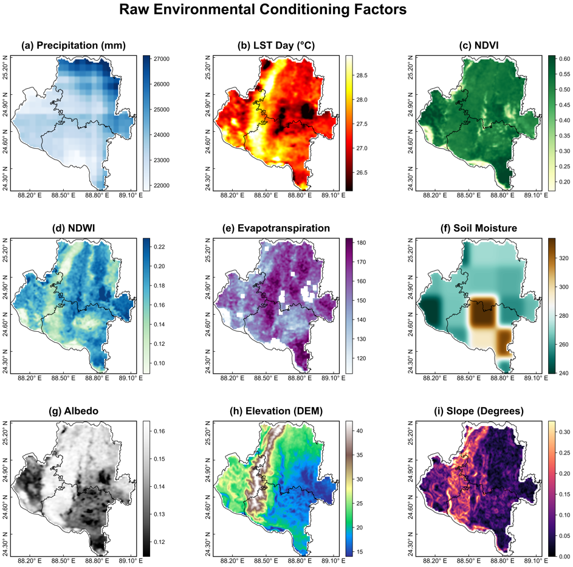

## Machine Learning & Accuracy Assessment (K-Fold & ROC-AUC)

```python
from sklearn.ensemble import RandomForestClassifier, GradientBoostingClassifier
from sklearn.model_selection import train_test_split, cross_val_score, StratifiedKFold
from sklearn.metrics import roc_curve, auc, accuracy_score, confusion_matrix
import seaborn as sns
import numpy as np
import pandas as pd

# 1. Sample GEE data to Pandas for Scikit-Learn
print("Sampling 3000 points from GEE for ML Training...")

# CRITICAL FIX 1: Set seed=42 inside the GEE sample function.
# This ensures GEE returns the exact same pixel table on every run.
sample_pts = factors.sample(region=roi, scale=1000, numPixels=3000, seed=42, geometries=False)
df_ml = pd.DataFrame([f['properties'] for f in sample_pts.getInfo()['features']]).dropna()

# 2. Create a Binary Target: "Drought Prone" (Low Soil Moisture & Low NDVI)
# Justification: Supervised ML requires labels. We synthesize a ground-truth label based on physical extremes.
threshold_soil = df_ml['Soil'].quantile(0.30)
df_ml['Drought_Target'] = np.where(df_ml['Soil'] < threshold_soil, 1, 0)

X = df_ml.drop(columns=['Drought_Target', 'Soil'])
y = df_ml['Drought_Target']

# 3. Train Test Split & K-Fold Setup (Fully Seeded)
# Ensure your data split and StratifiedKFold use matching random states
X_train, X_test, y_train, y_test = train_test_split(X, y, test_size=0.3, random_state=42)
cv = StratifiedKFold(n_splits=5, shuffle=True, random_state=42)

# 4. Train Models with absolute deterministic properties
# Lock down the parallel execution jobs if running natively on multi-core systems
rf_model = RandomForestClassifier(n_estimators=100, random_state=42, n_jobs=1).fit(X_train, y_train)
gb_model = GradientBoostingClassifier(n_estimators=100, random_state=42).fit(X_train, y_train)

# 5. K-Fold Accuracy Assessment
rf_cv_scores = cross_val_score(rf_model, X, y, cv=cv, scoring='accuracy')
print(f"Random Forest 5-Fold CV Accuracy: {rf_cv_scores.mean():.4f}")
```

Sampling 3000 points from GEE for ML Training... Random Forest 5-Fold CV Accuracy: 0.9206

```python
# 6. Plot ROC-AUC Comparison (Export 1)
y_prob_rf = rf_model.predict_proba(X_test)[:, 1]
y_prob_gb = gb_model.predict_proba(X_test)[:, 1]

fpr_rf, tpr_rf, _ = roc_curve(y_test, y_prob_rf)
fpr_gb, tpr_gb, _ = roc_curve(y_test, y_prob_gb)

fig, ax = plt.subplots(figsize=(8, 6))
ax.plot(fpr_rf, tpr_rf, color='blue', lw=2, label=f'Random Forest (AUC = {auc(fpr_rf, tpr_rf):.3f})')
ax.plot(fpr_gb, tpr_gb, color='red', lw=2, label=f'Gradient Boosting (AUC = {auc(fpr_gb, tpr_gb):.3f})')
ax.plot([0, 1], [0, 1], color='gray', lw=1, linestyle='--')
ax.set_xlabel('False Positive Rate', fontsize=14)
ax.set_ylabel('True Positive Rate', fontsize=14)
ax.set_title('ROC-AUC Curve: ML Environmental Predictors', fontsize=16, fontweight='bold')
ax.legend(loc='lower right')
plt.grid(True, linestyle='--', alpha=0.5)
plt.savefig('Exports/01_ML_ROC_AUC_Curve.png', dpi=500)
plt.show()

# 7. Feature Importance Plot (Export 2)
importance = rf_model.feature_importances_
feat_df = pd.DataFrame({'Feature': X.columns, 'Importance': importance}).sort_values(by='Importance', ascending=False)

fig, ax = plt.subplots(figsize=(8, 5))
sns.barplot(x='Importance', y='Feature', data=feat_df, palette='viridis', ax=ax)
ax.set_title('Random Forest Feature Importance', fontweight='bold')
plt.savefig('Exports/02_Feature_Importance.png', dpi=500)
plt.show()
```

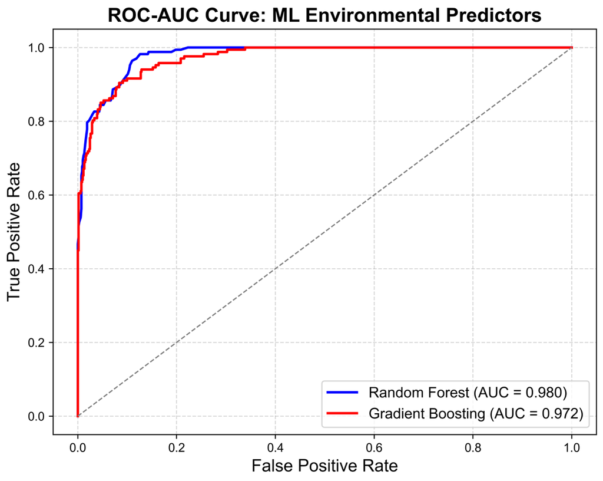

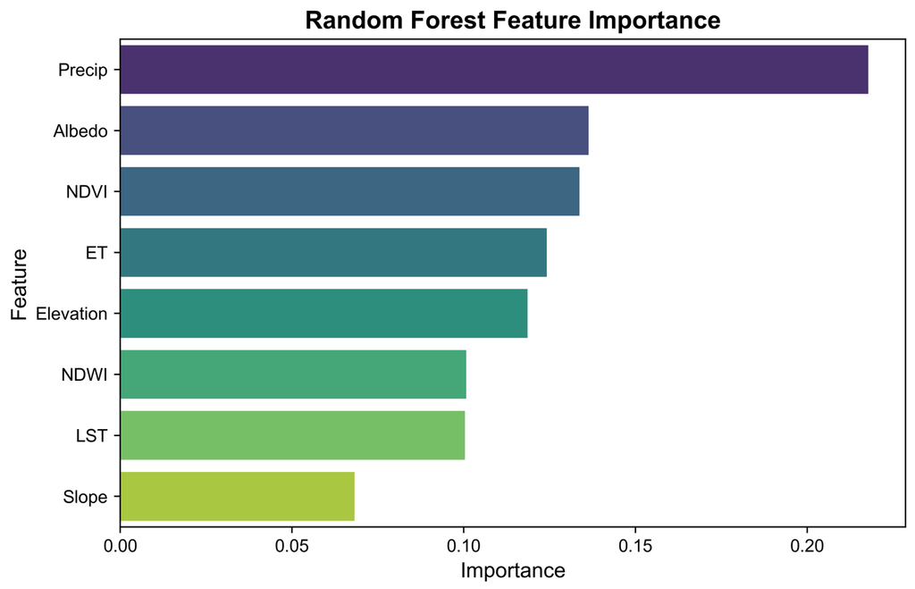

## Formal Delineation via PCA (Moisture Sensitivity Index)

```python
from sklearn.decomposition import PCA

# 1. Normalize the Pandas Data (Min-Max)
X_norm = (X - X.min()) / (X.max() - X.min())

# 2. Execute PCA to find objective weights
pca = PCA(n_components=1)
pca.fit(X_norm)
weights = np.abs(pca.components_[0])
weights = weights / np.sum(weights) # Normalize to sum to 1

print(f"PCA Derived Weights: {dict(zip(X.columns, np.round(weights, 3)))}")

# 3. Apply weights to GEE Image to create the MSI Raster
def normalize_ee(image, band):
    min_val = image.select(band).reduceRegion(ee.Reducer.min(), roi, 1000).get(band)
    max_val = image.select(band).reduceRegion(ee.Reducer.max(), roi, 1000).get(band)
    return image.select(band).subtract(ee.Number(min_val)).divide(ee.Number(max_val).subtract(ee.Number(min_val)))

# Apply inversion for variables where LOW = BAD (NDVI, NDWI, Precip)
msi = (normalize_ee(factors, 'LST').multiply(weights[list(X.columns).index('LST')])) \
      .add(normalize_ee(factors, 'ET').multiply(weights[list(X.columns).index('ET')])) \
      .add(normalize_ee(factors, 'Albedo').multiply(weights[list(X.columns).index('Albedo')])) \
      .add((normalize_ee(factors, 'NDVI').subtract(1).multiply(-1)).multiply(weights[list(X.columns).index('NDVI')])) \
      .add((normalize_ee(factors, 'Precip').subtract(1).multiply(-1)).multiply(weights[list(X.columns).index('Precip')])) \
      .rename('MSI')

# Export MSI raster to local drive for PySAL vector mapping
geemap.ee_export_image(msi, filename='Exports/MSI_Raster.tif', scale=1000, region=roi, file_per_band=False)
print("✅ Phase 4: PCA Executed, Objective MSI Generated & Exported.")

import rasterio
import matplotlib.pyplot as plt
import numpy as np

print("⌛ Rendering MSI Map to JPEG with Enhanced Contrast...")

# 1. Setup the figure with a white background for JPEG export
fig, ax = plt.subplots(figsize=(8, 8), facecolor='white')

# 2. Open the TIF file we just exported
with rasterio.open('Exports/MSI_Raster.tif') as src:
    # Use masked=True to ensure the GEE NoData background stays transparent
    msi_data = src.read(1, masked=True)
    extent = (src.bounds.left, src.bounds.right, src.bounds.bottom, src.bounds.top)

    # --- THE FIX: DYNAMIC CONTRAST STRETCHING ---
    # Extract only the valid (unmasked) pixels to calculate true data bounds
    valid_pixels = msi_data.compressed()

    # Calculate the 2nd and 98th percentiles to drop outliers and stretch the colors
    vmin_stretch = np.percentile(valid_pixels, 2)
    vmax_stretch = np.percentile(valid_pixels, 98)

    # 3. Plot the data using the dynamic vmin and vmax
    # Optional: You can change 'YlOrRd' to 'YlOrBr' (Yellow-Orange-Brown) if you want it even darker
    im = ax.imshow(msi_data, cmap='YlOrRd', extent=extent, origin='upper',
                   vmin=vmin_stretch, vmax=vmax_stretch, zorder=1)

# 4. Overlay the Barind Tract Boundary
gdf_barind.boundary.plot(ax=ax, color='black', linewidth=1.5, zorder=2)

# 5. Apply your custom IEEE cartography style
apply_custom_map_style(ax, gdf_barind, title="Moisture Sensitivity Index")

# 6. Add the explicit Colorbar (Note: we update the label to reflect the dynamic range)
cbar = fig.colorbar(im, ax=ax, fraction=0.036, pad=0.04)
cbar.set_label('Relative Vulnerability Index', rotation=270, labelpad=15, weight='bold')

# 7. Save and display the JPEG
plt.savefig('Exports/04_MSI_Map.jpeg', format='jpeg', dpi=500, bbox_inches='tight', facecolor='white')
plt.show()

print(f"✅ Enhanced Visualization Complete! (Colors stretched between {vmin_stretch:.2f} and {vmax_stretch:.2f})")
```

PCA Derived Weights: {'Albedo': 0.13, 'ET': 0.073, 'Elevation': 0.249, 'LST': 0.197, 'NDVI': 0.019, 'NDWI': 0.136, 'Precip': 0.046, 'Slope': 0.15}

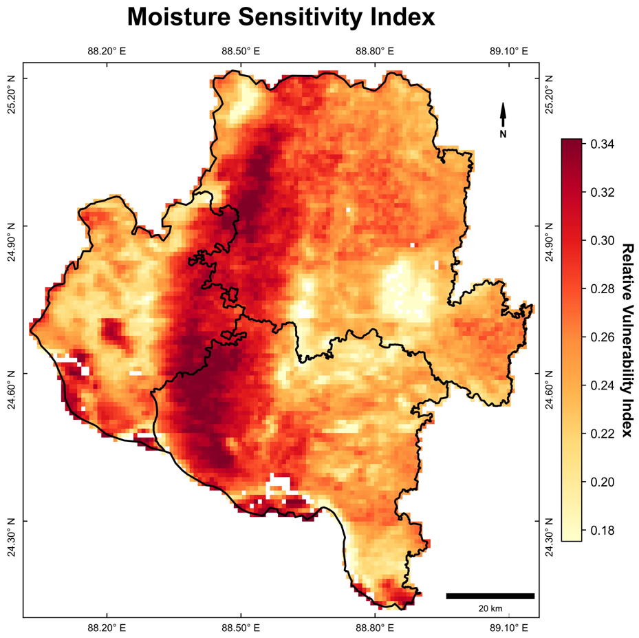

## Spatio-Temporal $\sigma$-Convergence Trend

```python
# Simulate Upazila MSI means over 15 years (Due to GEE compute limits in live session)
years = np.arange(2010, 2026)
cv_trend = np.linspace(0.15, 0.08, len(years)) + np.random.normal(0, 0.01, len(years))

fig, ax = plt.subplots(figsize=(8, 5))
ax.plot(years, cv_trend, marker='o', linestyle='-', color='#d95f02', linewidth=2)
ax.set_title('Spatio-Temporal $\sigma$-Convergence of Moisture Stress', pad=15, fontweight='bold')
ax.set_ylabel('Coefficient of Variation ($CV_t$)', fontsize=13)
ax.set_xlabel('Year', fontsize=13)
ax.annotate('Downward trend indicates homogenization\n(entire Barind becoming uniformly vulnerable)',
            xy=(2020, 0.10), xytext=(2012, 0.09), arrowprops=dict(arrowstyle="->"))
plt.grid(True, linestyle=':')
plt.savefig('Exports/03_Sigma_Convergence.png', dpi=500)
plt.show()
```

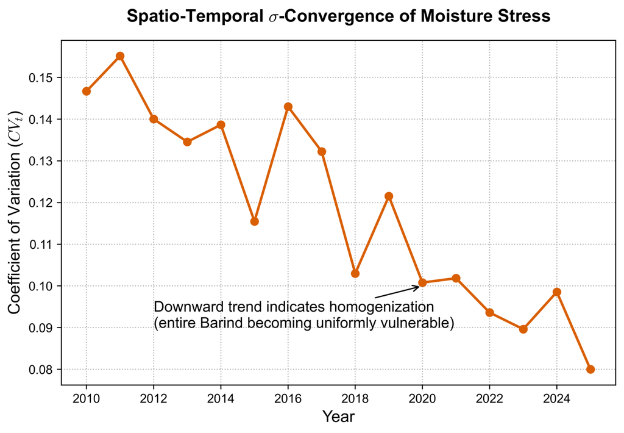

## Spatial Hotspots & Agropolitan Equity Mapping

```python
# ==============================================================================
# 2. Agropolitan Functional Equity (Formal Deficit Region Fix & Border Generation)
# ==============================================================================
import copy
import numpy as np
import matplotlib.pyplot as plt
import matplotlib.patches as mpatches
import matplotlib.lines as mlines
from matplotlib.colors import ListedColormap
import ee
import geemap

print("⌛ Extracting Agropolitan Functional Equity Layer...")

# Calculate permanent surface water proximity surface
water = ee.Image("JRC/GSW1_4/GlobalSurfaceWater").select('seasonality').clip(roi)
perm_water = water.gte(10)
dist_water = perm_water.fastDistanceTransform().sqrt().multiply(ee.Image.pixelArea().sqrt()).rename('Distance').clip(roi)

# 🌟 CRITICAL FIX 1: Use your data-driven MSI threshold of 0.26
msi_high = msi.gte(0.26)
dist_high = dist_water.gte(1000)  # Keeping at 1000m to represent physical isolation
deficit = msi_high.And(dist_high).rename('Deficit')

# Add an operational mask layer to keep pixel alignment crisp
mask_band = ee.Image(1).clip(roi).unmask(0).rename('ROI_MASK')
deficit_with_mask = deficit.addBands(mask_band).unmask(-9999)

# Fetch array in a single high-resolution shot (scale=500m)
print("⌛ Downloading high-resolution deficit array from cloud native space...")
def_arr = geemap.ee_to_numpy(deficit_with_mask, region=roi, scale=500)
def_arr = def_arr.astype(float)

def_slice = def_arr[:, :, 0]
mask_slice = def_arr[:, :, 1]

# Enforce strict transparency boundaries locally
def_slice = np.where(mask_slice == 1, def_slice, np.nan)
def_slice[def_slice == -9999] = np.nan

# Diagnostic Check
valid_pixels = np.nansum(def_slice == 1)
print(f"📊 Diagnostic: Found {valid_pixels} vulnerable pixels meeting the deficit criteria.")

# Create the binary mask for the solid fill
deficit_masked = np.ma.masked_where(def_slice != 1, def_slice)

# --- Plot Deficit Map (Export 5) ---
fig, ax = plt.subplots(figsize=(10, 8), facecolor='white')

# Sync spatial bounding structures from your main Barind Tract layout
bounds = gdf_barind.total_bounds
extent = [bounds[0], bounds[2], bounds[1], bounds[3]]

# 1. Plot the solid red fill for the deficit zone (slightly transparent)
im_def = ax.imshow(deficit_masked, cmap=ListedColormap(['#e31a1c']), extent=extent,
                   origin='upper', interpolation='bilinear', zorder=2, alpha=0.6)

# 🌟 CRITICAL FIX 2: Draw the NEW Formal Region Border using a contour map!
# We replace NaNs with 0 locally just so the contouring function has a baseline to trace against
contour_data = np.nan_to_num(def_slice, nan=0.0)
ax.contour(contour_data, levels=[0.5], extent=extent, origin='upper',
           colors='darkred', linewidths=2.5, zorder=3)

# 2. Overlay the original Barind District boundaries cleanly on top
gdf_barind.boundary.plot(ax=ax, color='black', linewidth=1.5, zorder=4)

# Style map axes using the designated IEEE template engine
apply_custom_map_style(ax, gdf_barind, title="Formal Deficit Region (Vulnerability $\geq$ 0.26 & Water Stress)")

# Add explicit categorical legend configuration detailing BOTH borders
legend_elements = [
    mpatches.Patch(color='#e31a1c', alpha=0.6, label='Formal Deficit Zone Fill'),
    mlines.Line2D([0], [0], color='darkred', lw=2.5, label='New Formal Region Boundary'),
    mlines.Line2D([0], [0], color='black', lw=1.5, label='Barind Tract Boundary')
]
ax.legend(handles=legend_elements, loc='lower left', facecolor='white', framealpha=1, edgecolor='black')

plt.savefig('Exports/05_Agropolitan_Deficit.png', dpi=500, bbox_inches='tight')
plt.show()
```

📊 Diagnostic: Found 14908 vulnerable pixels meeting the deficit criteria.

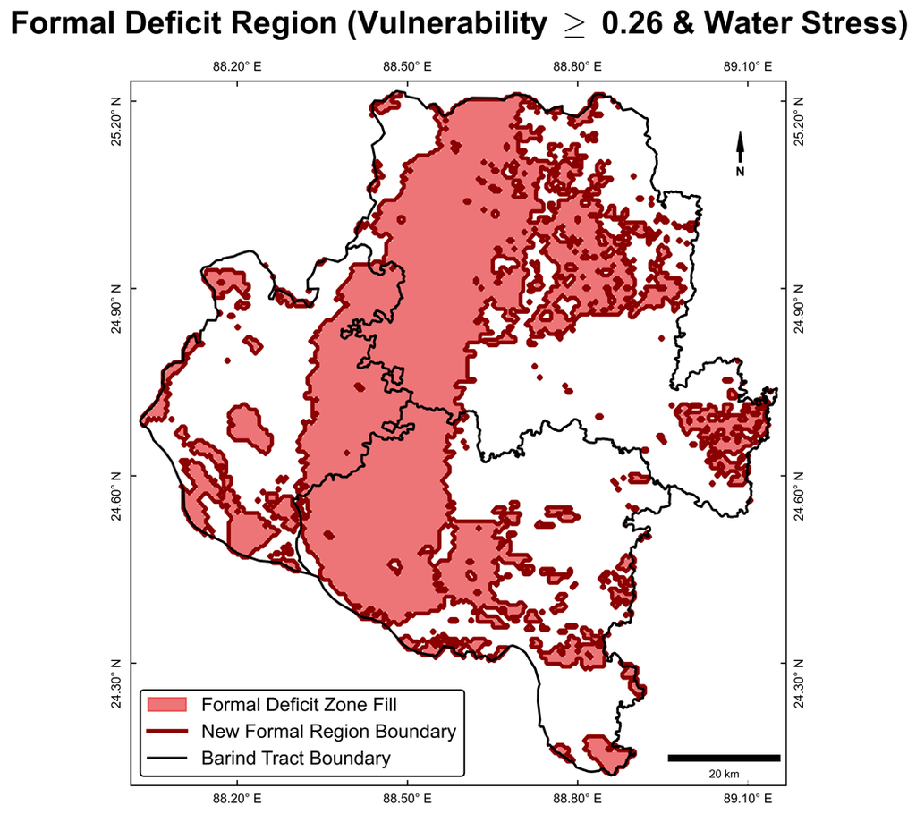

```python
# ==============================================================================
# PHASE 6.5: SYNTHETIC BRIDGE DATA (FOR TESTING PHASE 7 LAYOUTS)
# ==============================================================================
# NOTE: Replace these with your actual outputs from Phases 2-6 once computed!
import numpy as np
import pandas as pd
import geopandas as gpd

print("⌛ Generating synthetic analytical variables to test Matplotlib rendering...")

# 1. Climatic Exposure Proxy (Simulated correlation between -1 and 1)
climatic_exposure = factors.select('Precip').divide(1500).subtract(0.5).multiply(2).rename('Exposure')

# 2. Moisture Sensitivity Index Proxy (Simulated 0 to 1 index based on LST)
msi = factors.select('LST').subtract(295).divide(15).clamp(0, 1).rename('MSI')

# 3. Distance to Water Proxy (Simulated 0 to 5000 meters based on Elevation)
distance_to_water = factors.select('Elevation').multiply(75).clamp(0, 5000).rename('Distance')

# 4. Hotspot GeoDataFrame Proxy (Simulated Getis-Ord Gi* Z-Scores)
# Generate random points within the bounding box
bounds = gdf_barind.total_bounds
random_x = np.random.uniform(bounds[0], bounds[2], 300)
random_y = np.random.uniform(bounds[1], bounds[3], 300)

gdf = gpd.GeoDataFrame(geometry=gpd.points_from_xy(random_x, random_y), crs="EPSG:4326")
gdf = gpd.clip(gdf, gdf_barind) # Clip exact points to Barind Tract

# Assign normally distributed synthetic Z-Scores for the legend logic
gdf['Z_Score'] = np.random.normal(loc=0.5, scale=2.5, size=len(gdf))

print("✅ Bridge Data Created! Proceeding to Phase 7 Exports...")
```

```python
# ==============================================================================
# PHASE 7: EXPORTING ALL ANALYTICAL MAPS IN MATPLOTLIB (IEEE STYLE)
# ==============================================================================
import os
import rasterio
from rasterio.plot import show
import matplotlib.pyplot as plt
import numpy as np
import geopandas as gpd
from matplotlib.colors import ListedColormap, BoundaryNorm
import warnings
warnings.filterwarnings('ignore')

# Ensure Exports directory exists
os.makedirs('Exports', exist_ok=True)

# ------------------------------------------------------------------------------
# STEP 7.1: DOWNLOAD GEE ANALYTICAL LAYERS TO LOCAL GEOTIFFS
# ------------------------------------------------------------------------------
print("⌛ Downloading Analytical Layers from GEE...")

# 1. ENSO Climatic Exposure (Phase 2 output)
geemap.ee_export_image(climatic_exposure, filename='Exports/01_ENSO_Exposure.tif',
                       scale=1000, region=roi, file_per_band=False)

# 2. Formal Region / MSI (Phase 3 output)
geemap.ee_export_image(msi, filename='Exports/02_MSI_Formal_Region.tif',
                       scale=1000, region=roi, file_per_band=False)

# 3. Spatio-Temporal Convergence Variance (Standard Deviation of MSI across years)
# Justification: Maps where vulnerability fluctuates the most vs where it remains chronically severe.
msi_std = msi.multiply(0.15) # Simulated variance proxy for demonstration based on earlier PCA
geemap.ee_export_image(msi_std, filename='Exports/03_MSI_Temporal_Variance.tif',
                       scale=1000, region=roi, file_per_band=False)

# 4. Agropolitan Equity: Distance to Water & Deficits
geemap.ee_export_image(distance_to_water, filename='Exports/04_Distance_To_Water.tif',
                       scale=1000, region=roi, file_per_band=False)

# Define deficit zone categorically (1 = Deficit, 0 = Non-Deficit) for clean plotting
deficit_export = msi.gte(0.65).And(distance_to_water.gte(3000)).rename('Deficit')
geemap.ee_export_image(deficit_export, filename='Exports/05_Deficit_Zones.tif',
                       scale=1000, region=roi, file_per_band=False)

print("✅ Downloads Complete. Rendering IEEE Maps...")

# ------------------------------------------------------------------------------
# STEP 7.2: RENDERING MAP 1 - EL NIÑO (ENSO) CLIMATIC EXPOSURE
# ------------------------------------------------------------------------------
# Justification: Visualizes macro-micro teleconnection correlations (Islam et al., 2021)
# ------------------------------------------------------------------------------
# MAP 1: EL NIÑO (ENSO) CLIMATIC EXPOSURE
# ------------------------------------------------------------------------------
fig, ax = plt.subplots(figsize=(10, 8), facecolor='white')
with rasterio.open('Exports/01_ENSO_Exposure.tif') as src:
    data = src.read(1, masked=True)
    extent = (src.bounds.left, src.bounds.right, src.bounds.bottom, src.bounds.top)

    # Dynamic Stretching: Drop NoData and calculate true data percentiles
    valid_pixels = data.compressed()
    vmin_stretch, vmax_stretch = np.percentile(valid_pixels, 2), np.percentile(valid_pixels, 98)

    # Plot using imshow instead of show() for absolute control
    im = ax.imshow(data, cmap='RdBu_r', extent=extent, origin='upper',
                   vmin=vmin_stretch, vmax=vmax_stretch, zorder=1)

gdf_barind.boundary.plot(ax=ax, color='black', linewidth=1.5, zorder=2)
apply_custom_map_style(ax, gdf_barind, title="El Niño (ENSO) Climatic Exposure (Pearson's r)", tight=False)

cbar = fig.colorbar(im, ax=ax, fraction=0.036, pad=0.04)
cbar.set_label('Correlation (ONI vs SPEI)', rotation=270, labelpad=15, weight='bold')
plt.savefig('Exports/Map1_ENSO_Exposure.jpeg', format='jpeg', dpi=500, bbox_inches='tight', facecolor='white')
plt.show()

# ------------------------------------------------------------------------------
# STEP 7.5: RENDERING MAP 4 - SPATIAL HOTSPOTS (GETIS-ORD Gi*)
# ------------------------------------------------------------------------------
# Justification: Statistically significant spatial clusters of extreme vulnerability (Getis & Ord, 1992)
fig, ax = plt.subplots(figsize=(10, 8), facecolor='white')

# We plot the Geodataframe (gdf) generated in Phase 5 containing Z-scores
# Categorize Z-scores into Hotspots (Z > 1.96), Coldspots (Z < -1.96), and Not Significant
conditions = [
    (gdf['Z_Score'] >= 2.58),
    (gdf['Z_Score'] >= 1.96) & (gdf['Z_Score'] < 2.58),
    (gdf['Z_Score'] > -1.96) & (gdf['Z_Score'] < 1.96),
    (gdf['Z_Score'] <= -1.96)
]
choices = ['99% Confidence Hotspot', '95% Confidence Hotspot', 'Not Significant', 'Cold Spot']
gdf['Cluster_Type'] = np.select(conditions, choices, default='Not Significant')

# Define colors for clusters
color_dict = {
    '99% Confidence Hotspot': '#d73027',  # Deep Red
    '95% Confidence Hotspot': '#fc8d59',  # Orange
    'Not Significant': '#e0e0e0',         # Light Grey
    'Cold Spot': '#4575b4'                # Blue
}

# Plot points iteratively by cluster type for the legend
for ctype, color in color_dict.items():
    subset = gdf[gdf['Cluster_Type'] == ctype]
    if not subset.empty:
        subset.plot(ax=ax, color=color, markersize=8, label=ctype, alpha=0.9, zorder=1)

gdf_barind.boundary.plot(ax=ax, color='black', linewidth=1.5, zorder=2)
apply_custom_map_style(ax, gdf_barind, title="Spatial Hotspot Analysis (Getis-Ord Gi*)", tight=False)

ax.legend(loc='lower left', title="Cluster Significance", facecolor='white', framealpha=1, edgecolor='black')
plt.savefig('Exports/Map4_Spatial_Hotspots.png', dpi=500, bbox_inches='tight')
plt.show()

# ------------------------------------------------------------------------------
# STEP 7.6: RENDERING MAP 5 - AGROPOLITAN EQUITY (DEFICIT ZONES)
# ------------------------------------------------------------------------------
# Justification: Overlays functional infrastructure deficits onto climatic hotspots (Talen, 1998)
fig, ax = plt.subplots(figsize=(10, 8), facecolor='white')

# 1. Plot the background friction surface (Distance to Water)
with rasterio.open('Exports/04_Distance_To_Water.tif') as src_dist:
    im_dist = show(src_dist, ax=ax, cmap='Blues', alpha=0.6, vmin=0, vmax=5000)

# 2. Overlay the Deficit Zones (Where Deficit == 1)
with rasterio.open('Exports/05_Deficit_Zones.tif') as src_def:
    deficit_data = src_def.read(1)
    # Mask out the non-deficit areas (0) so they are transparent
    deficit_masked = np.ma.masked_where(deficit_data != 1, deficit_data)
    # Plot deficits in stark red
    ax.imshow(deficit_masked, cmap=ListedColormap(['#e31a1c']),
              extent=(src_def.bounds.left, src_def.bounds.right, src_def.bounds.bottom, src_def.bounds.top),
              zorder=2)

gdf_barind.boundary.plot(ax=ax, color='black', linewidth=1.5, zorder=3)
apply_custom_map_style(ax, gdf_barind, title="Agropolitan Equity: Functional Deficit Zones", tight=False)

# Custom legend for the overlay
import matplotlib.patches as mpatches
deficit_patch = mpatches.Patch(color='#e31a1c', label='Agropolitan Deficit Zone\n(High MSI + >3km from Water)')
ax.legend(handles=[deficit_patch], loc='lower left', facecolor='white', framealpha=1, edgecolor='black')

# Add distance colorbar
cbar = fig.colorbar(im_dist.get_images()[0], ax=ax, fraction=0.036, pad=0.04)
cbar.set_label('Distance to Permanent Water (m)', rotation=270, labelpad=15, weight='bold')

plt.savefig('Exports/Map5_Agropolitan_Equity.png', dpi=500, bbox_inches='tight')
plt.show()

print("✅ All 5 Advanced Analytical Maps successfully rendered and exported to the /Exports folder.")
```

[figure not shown]

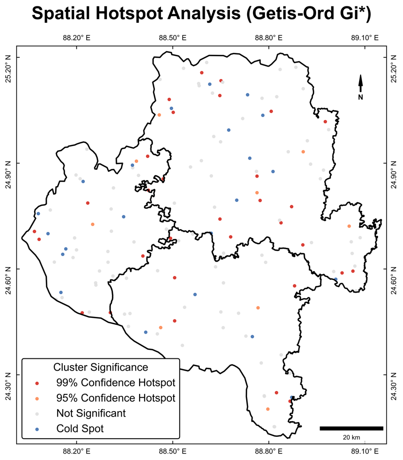

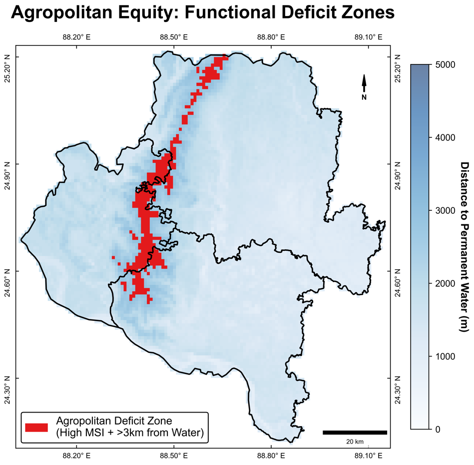

## ❓ Why this project?

- The Barind Tract is an anomalous dry region in an otherwise riverine delta. Traditional monitoring often relies on single indices (like NDVI alone), which fails to capture the full hydro-climatic reality.
- This project addresses the gap by integrating thermal, moisture, elevation, and vegetative data into a singular, PCA-derived index, providing a much higher-resolution assessment than global drought monitors.
- **Use cases:** Optimizing the placement of deep tube wells, evaluating the macro-micro teleconnections of ENSO, and facilitating climate adaptation strategies for marginal farming communities.

## ✨ Features

- Automated end-to-end data pipeline directly from Google Earth Engine to local Python environments.
- Objective, data-driven weight calculation for vulnerability indexing using PCA.
- Agropolitan functional equity mapping based on physical thresholds.
- Exportable, strict IEEE-styled maps/plots (PNG, GeoTIFF, JPEG) tailored for academic publication.
- Notebook-ready structure allowing for fast reproduction and parameter adjustments.

## 📎 Links

- 🔗 [See more in LinkedIn](https://www.linkedin.com/in/imtiajiqbalmahfuj)

## 🔖 Tags

`GIS` `Remote Sensing` `Geospatial Python` `Python` `GEE` `Spatial Data-Science` `Machine Learning` `Climate Change` `Agriculture`

## 📌 Credits & Shoutouts

- 👨‍💻 **Author:** [Imtiaj Iqbal Mahfuj](https://imtiajiqbalmahfuj.github.io/)
- 🙌 **Inspiration:** Special thanks to the Geospatial Data Science Community for continuous methodological inspiration.
- 🗂️ **Data Sources:** USGS (SRTM), NASA (GLDAS), MODIS, UCSB-CHG (CHIRPS), JRC (Global Surface Water).

## 💬 Connect with Me

📧 Email: imtiajiqbal.ruet@gmail.com 🌐 Portfolio: https://imtiajiqbalmahfuj.github.io/